# Gender and MBTI-Style Personality Traits as Predictors of STEM Interest and Instructional-Style Preference

STAT340 — Compulsory Assignment

Sølve Langseth

April 2025

```r
# All packages used in the report, loaded once so that later chunks can be
# re-run in any order without hitting "could not find function" errors.
# Deliberately limited to widely-available packages so the document knits on a
# stock R installation without a compiler toolchain.
library(dplyr)
library(tidyr)
library(ggplot2)
library(knitr)
library(broom)
library(cluster)  # pam(), silhouette()
```

## 1 Introduction

Interest in science, technology, engineering, and mathematics (STEM) is widely recognized as a key driver of future career choices and innovation. Yet students’ enthusiasm for STEM subjects often varies along demographic and personality dimensions, and is shaped in part by the way material is presented and delivered. Laboratory research in accounting education has demonstrated that instructional style can significantly affect student performance, engagement, and satisfaction (Hartnett et al., 2003).

In this paper, we address two interlinked questions:

1. **Personality & STEM enthusiasm.** To what extent do sex and MBTI-style traits predict pupils’ overall STEM-interest scores?
2. **Persona-driven pedagogy.** Can those same traits infer each pupil’s optimal instructional-style persona — “Discussion-oriented” versus “Independent/hands-on” — as derived from PCA of teaching-preference items and PAM clustering?

To answer these, we employ four complementary methods — multiple linear regression, principal component analysis (PCA), PAM clustering, and logistic regression — each trained on the Train set and validated on the Test set. This framework not only quantifies which personality dimensions drive STEM-interest, but also demonstrates how a brief personality inventory could guide educators toward the most effective teaching format for individual students.

# 2 Methods

## 2.1 Data & Preprocessing

```r
# The .Rdata file restores two data frames into the global environment:
# `Train` and `Test`, 5 000 pupils each.
load("../data/CompulsorySTAT340.Rdata")

# An integer ID keeps rows traceable after the joins and cluster assignments
# performed further down.
Train$ID <- seq_len(nrow(Train))
Test$ID  <- seq_len(nrow(Test))

# The raw personality columns are stored as 0/1 flags. Recoding them into
# labelled factors makes every downstream model summary self-documenting:
# the coefficient reads "SexM" or "FF" rather than "Sex1" or "F1".
recode_mbti <- function(df) {
  df %>%
    mutate(
      Sex       = factor(Sex, levels = c("F", "M"), labels = c("F", "M")),
      I         = factor(I,   levels = 0:1, labels = c("E", "I")),  # Extravert / Introvert
      S         = factor(S,   levels = 0:1, labels = c("N", "S")),  # iNtuitive / Sensing
      F         = factor(F,   levels = 0:1, labels = c("T", "F")),  # Thinking  / Feeling
      C         = factor(C,   levels = 0:1, labels = c("D", "C")),  # Digital   / Contextual
      Age_group = factor(Age,
                         levels = c(1, 13, 16, 19, 30),
                         labels = c("1–12", "13–15", "16–18", "19–30", "30+"))
    )
}

Train <- recode_mbti(Train)
Test  <- recode_mbti(Test)
```

Table 1. Level counts for sex and the MBTI-style dichotomies (Train set)

| Variable | Level | n |
| --- | --- | --- |
| C | C | 2615 |
| C | D | 2385 |
| F | F | 3035 |
| F | T | 1965 |
| I | E | 2650 |
| I | I | 2350 |
| S | S | 2849 |
| S | N | 2151 |
| Sex | F | 3231 |
| Sex | M | 1769 |

**Preprocessing steps.** We added an integer ID to preserve Train/Test pairing, recoded the 0/1 personality flags into labeled factors, and centered + scaled the nine instructional-preference items (so each has mean 0 and unit variance) for PCA. **Table 1** summarizes the factor distributions in the Train set.

## 2.2 Descriptive Statistics and Model Justification

Before fitting any of our core models, we conducted descriptive analyses of the key variables — examining distributions, checking for outliers or skewness, and exploring group differences — to (1) verify that each outcome and predictor met the necessary assumptions, (2) identify which covariates (e.g. sex) merited inclusion, and (3) inform the choice of dimension-reduction and clustering methods.

### Overall STEM interest

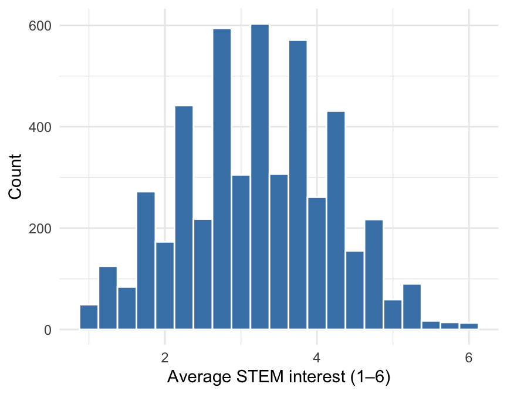

Figure 1: Distribution of average STEM interest (1–6)

### Math interest by sex

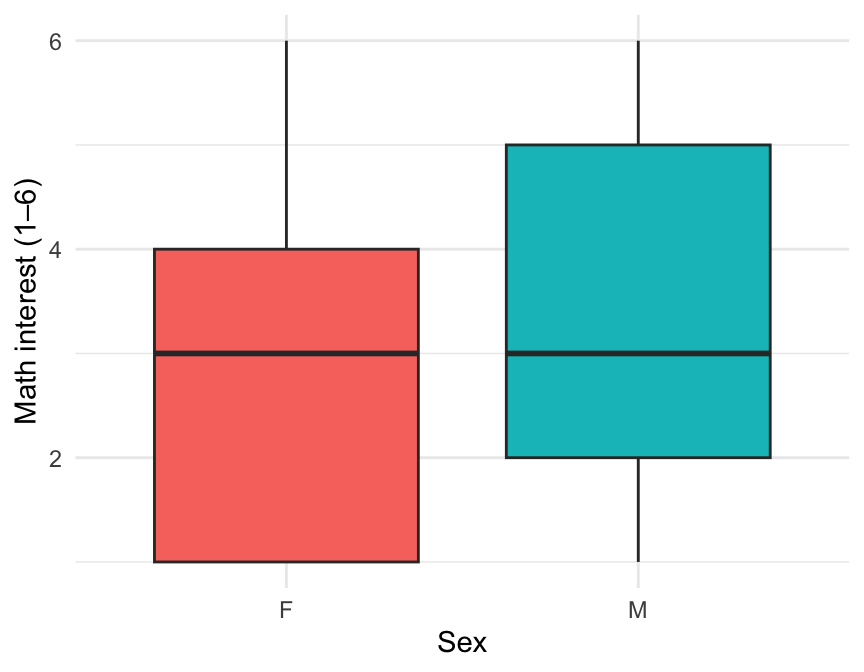

Figure 2: Mathematics interest by sex

**Figure 2** Both sexes have the same median math-interest (level 3), but the male distribution is more spread out toward the top end: 25 % of boys score 5 or 6, whereas girls’ upper quartile tops out around 4.

### Summary

The histogram of **Mean_STEM** is approximately bell-shaped and centered near the scale midpoint, supporting its treatment as a continuous outcome in a linear model. Boxplots of math interest by sex (Figure 2) reveal that, while medians coincide at 3, boys show a heavier upper tail (25 % scoring ≥ 5 versus girls’ upper quartile at 4). Although our primary focus is on instructional-style effects, this pronounced gender gap must be accounted for — otherwise the model might attribute differences in STEM interest to teaching preferences that actually stem from unadjusted sex differences. Accordingly, we include **Sex** as a covariate alongside the four MBTI dimensions in our first inferential model.

## 2.3 Multiple Linear Regression: Overall STEM Interest

To quantify how sex and MBTI-style personality traits relate to overall STEM enthusiasm, we fitted a multiple linear regression model with **Mean_STEM** as the response and **Sex**, **I**, **S**, **F**, and **C** as predictors.

```r
m1 <- lm(Mean_STEM ~ Sex + I + S + F + C, data = Train)

# R² is quoted in the prose below, so pull it out rather than hard-coding it.
r2_val <- round(summary(m1)$r.squared, 3)
```

Table 2. Regression coefficients predicting mean STEM interest

| Term | Estimate | Std. Error | p-value |
| --- | --- | --- | --- |
| (Intercept) | 3.228 | 0.036 | <0.001 |
| SexM | 0.247 | 0.029 | <0.001 |
| II | 0.141 | 0.028 | <0.001 |
| SS | 0.054 | 0.029 | 0.06 |
| FF | -0.187 | 0.028 | <0.001 |
| CC | -0.173 | 0.028 | <0.001 |

## 2.4 Principal Component Analysis: Instructional Style

To summarize students’ preferences on the instructional-style items, we perform a PCA and keep the components carrying the largest variance. Note that although the items are numbered up to I12, only **nine** of them are present in the delivered data (I1, I3, I4, I6, I7, I8, I9, I10 and I12); I2, I5 and I11 were not included. The PCA is therefore run on nine variables.

```r
# Select the instructional-style items by name pattern rather than by position,
# so the code does not break if the column order in the source data changes.
# Note this yields nine items, not twelve — the numbering in the questionnaire
# is not contiguous.
instr_vars <- grep("^I\\d+$", names(Train), value = TRUE)

pc_obj <- prcomp(Train[, instr_vars], center = TRUE, scale. = TRUE)

# Attach the first two component scores to both sets. The Test scores are
# obtained by projecting onto the Train rotation — never by re-fitting a PCA on
# the Test data, which would leak information and change the axes.
Train$PC1 <- pc_obj$x[, 1]
Train$PC2 <- pc_obj$x[, 2]
Test[, c("PC1", "PC2")] <- predict(pc_obj, newdata = Test[, instr_vars])[, 1:2]

# Percentage of variance explained, quoted inline in the text below.
var_PC1 <- round(100 * summary(pc_obj)$importance[2, 1], 1)
var_PC2 <- round(100 * summary(pc_obj)$importance[2, 2], 1)
```

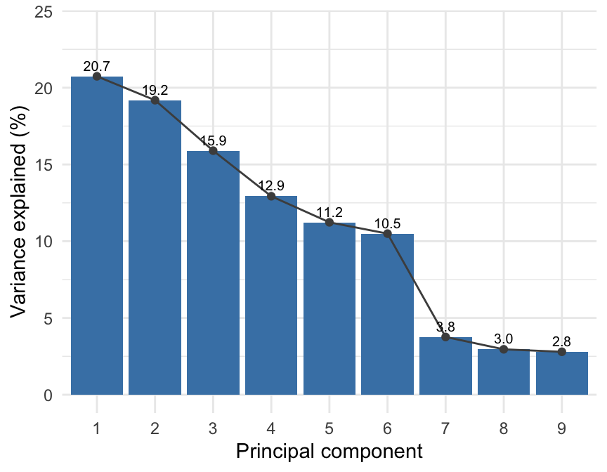

Figure 3: Scree plot of the instructional-style PCA

**Figure 3** shows that PC1 and PC2 together account for ~40 % of the variance (PC1 = 20.7 %, PC2 = 19.2 %). We focus on these two components because adding PC3 reduced clustering quality (average silhouette width fell from 0.341 to 0.250).

Table 3. Loadings above |0.25| on PC1 (20.7 %) and PC2 (19.2 %)

| Item | Description | PC1 | PC2 |
| --- | --- | --- | --- |
| I3 | Abductive Theoretical Instruction | 0.349 | -0.376 |
| I4 | Dialog and Group Oriented Theoretical Instruction | 0.105 | 0.483 |
| I6 | Methodological Formula Oriented Instruction | -0.574 | -0.006 |
| I7 | Explorative Inspirational Instruction | 0.287 | -0.512 |
| I8 | Dialog based Inspirational Instruction | 0.216 | 0.531 |
| I9 | Practical Problem based Instruction | 0.294 | 0.099 |
| I10 | Instrumental Procedure Oriented Instruction | -0.550 | -0.082 |

The loadings reveal two complementary dimensions of instructional preference:

**PC 1 – “Exploratory vs. Formulaic Structure”** This component captures how much structure students prefer in their learning environment. At the positive end, we see strong contributions from *Abductive Theoretical Instruction* (I3, +0.35), *Practical Problem-based Instruction* (I9, +0.29) and *Explorative Inspirational Instruction* (I7, +0.29) — formats that emphasize conceptual thinking and open-ended enquiry. On the negative end are *Methodological Formula-Oriented Instruction* (I6, –0.57) and *Instrumental Procedure-Oriented Instruction* (I10, –0.55), which represent highly structured, step-by-step teaching. Students with high PC 1 scores tend to prefer loosely structured, theory-led exploration, while those with low scores are more comfortable with precise, rule-based guidance.

**PC 2 – “Collaborative vs. Independent Engagement”** This axis reflects students’ preferred mode of interaction. Positive loadings come from *Dialog-based Inspirational Instruction* (I8, +0.53) and *Dialog and Group Oriented Theoretical Instruction* (I4, +0.48), indicating a preference for collaborative learning and teacher feedback. At the negative end, *Explorative Inspirational Instruction* (I7, –0.51) and *Abductive Theoretical Instruction* (I3, –0.38) signal a tendency toward self-directed discovery with minimal verbal instruction. Students who score high on PC 2 thrive in collaborative, discussion-based settings, whereas those who score low prefer independent, exploratory work.

Note that I3 and I7 load on both axes with opposite signs: both describe open-ended instruction, but PC 2 separates whether that openness happens *in dialogue with others* or *alone*.

Together, these two orthogonal components summarize students’ instructional preferences along two core dimensions — level of structure and mode of engagement — and serve as the basis for our subsequent clustering analysis.

## 2.5 Clustering: Learner Personas

To identify broad learner personas based on instructional preferences, we applied PAM (partitioning around medoids) clustering to the first two principal components. PAM is preferred over k-means here because medoids are actual observations, which makes each persona directly interpretable as a representative pupil.

```r
# Two clusters, fitted on the Train PC scores only.
pam2 <- pam(Train[, c("PC1", "PC2")], k = 2)

cat("k = 2 average silhouette width:", round(pam2$silinfo$avg.width, 3), "\n")
```

```
## k = 2 average silhouette width: 0.341
```

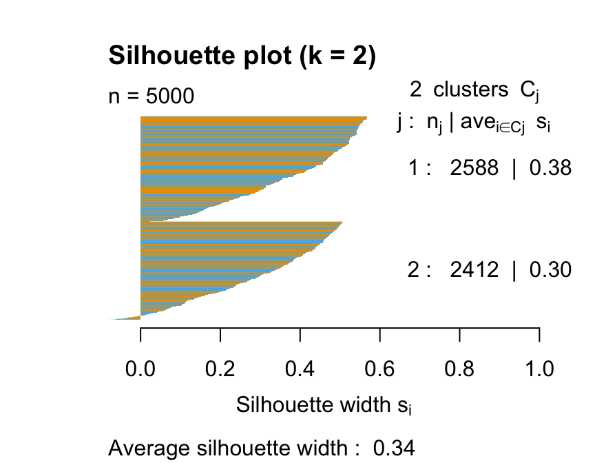

Figure 4: Silhouette plot for k = 2

```r
# Label the clusters by persona now, so that every table, plot and model
# summary downstream reports the same two names.
persona_levels <- c("Discussion-oriented", "Independent/hands-on")
Train$learner_cluster <- factor(pam2$clustering, labels = persona_levels)

# Medoid coordinates drive the Test-set assignment below.
medoids2 <- pam2$medoids[, c("PC1", "PC2")]
```

**Figure 4** shows that k = 2 gives reasonable cluster separation (average silhouette width = 0.34).

[figure not shown]

Figure 5: Learner personas in PC1–PC2 space

## 2.6 Logistic Regression: Predicting the Persona

```r
# Assign each Test pupil to the nearest Train medoid in PC1–PC2 space. The
# labels must match `persona_levels` exactly, otherwise the confusion matrix
# below would compare two differently-labelled factors.
Test$learner_cluster <- factor(
  apply(Test[, c("PC1", "PC2")], 1, function(z) {
    d <- sqrt((z[1] - medoids2[, "PC1"])^2 + (z[2] - medoids2[, "PC2"])^2)
    which.min(d)
  }),
  levels = 1:2,
  labels = persona_levels
)
```

```r
# Can sex and the four MBTI traits recover the persona? Fitted on Train,
# evaluated on the untouched Test set.
glm2 <- glm(learner_cluster ~ Sex + I + S + F + C,
            data = Train, family = binomial)

# glm models the probability of the SECOND factor level, i.e. P(Independent/hands-on).
prob2 <- predict(glm2, newdata = Test, type = "response")
pred2 <- factor(ifelse(prob2 > 0.5, persona_levels[2], persona_levels[1]),
                levels = persona_levels)

cm <- table(True = Test$learner_cluster, Predicted = pred2)
cm
```

```
##                       Predicted
## True                   Discussion-oriented Independent/hands-on
##   Discussion-oriented                 1814                  730
##   Independent/hands-on                1073                 1383
```

```r
acc <- sum(diag(cm)) / sum(cm)
cat("Accuracy on Test set:", round(acc, 3), "\n")
```

```
## Accuracy on Test set: 0.639
```

Table 4. Odds ratios (95 % CI) for predicting learner persona

| Term | Odds ratio | CI low | CI high | p-value |
| --- | --- | --- | --- | --- |
| (Intercept) | 1.383 | 1.189 | 1.609 | 0.000 |
| SexM | 1.183 | 1.045 | 1.338 | 0.008 |
| II | 0.752 | 0.667 | 0.847 | 0.000 |
| SS | 0.332 | 0.294 | 0.375 | 0.000 |
| FF | 1.079 | 0.955 | 1.218 | 0.221 |
| CC | 1.638 | 1.453 | 1.848 | 0.000 |

We fitted a logistic regression model to predict each pupil’s instructional-style persona — “Discussion-oriented” vs “Independent/hands-on” — based on sex and MBTI-style traits. On the independent Test set, the model achieved **64 % accuracy**.

The most predictive traits were **Contextuality** (OR = 1.64, p < 0.001), **Extraversion** (OR = 1.33, inverse of the Introvert OR), and **Sex** (males more likely to prefer independent/hands-on formats, OR = 1.18, p = 0.008). Sensing types were strongly associated with the discussion-oriented persona (OR = 0.33, p < 0.001).

These results suggest that basic personality indicators can offer **moderate predictive power** in identifying a pupil’s preferred learning style.

# 3 Results

## 3.1 Multiple Linear Regression: Overall STEM Interest

The regression of **Mean_STEM** on sex and MBTI traits revealed the following:

- **Sex (M):** +0.25 (p < 0.001), indicating that male pupils report, on average, a quarter-point higher STEM interest than females.
- **Introversion (I):** +0.14 (p < 0.001), showing that introverts rate STEM higher than extraverts.
- **Sensing (S):** +0.05 (p ≈ 0.06), a borderline effect suggesting slightly higher STEM interest among sensors.
- **Feeling (F):** –0.19 (p < 0.001), indicating lower STEM interest for feelers.
- **Contextual (C):** –0.17 (p < 0.001), indicating lower STEM interest for contextual learners.

These results confirm clear gender and personality influences on overall STEM enthusiasm.

## 3.2 PCA of Instructional Preferences & Clustering of Learner Personas

- **PCA:** The first two components captured ≈ 40 % of the variance across the nine teaching-preference items:
  - **PC1** (20.7 %): Exploratory ↔︎ Formulaic
  - **PC2** (19.2 %): Collaborative ↔︎ Independent
- **Clustering:** PAM clustering on PC1 and PC2 with **k = 2** identified two broad instructional-style personas:
  - **Cluster 1 – “Discussion-oriented”**: pupils who prefer collaborative and dialog-heavy formats.
  - **Cluster 2 – “Independent/hands-on”**: pupils who prefer self-paced, solitary, or experiential learning.

Silhouette analysis supported moderate clustering quality (width ≈ 0.341), and cluster interpretation was guided by medoid positions on the PC1–PC2 plane.

## 3.3 Logistic Regression: Predicting Learner Persona

To assess whether a pupil’s instructional-style persona could be predicted from basic personal traits, we fitted a logistic regression with cluster membership as the outcome. On the Test set, the model achieved **64 % accuracy**.

Key effects included:

- **Contextual (C):** OR = 1.64 (p < 0.001) – more likely to be “Independent/hands-on”
- **Sex (M):** OR = 1.18 (p = 0.008) – males favoured “Independent/hands-on”
- **Introversion (I):** OR = 0.75 (p < 0.001) – introverts leaned “Discussion-oriented”
- **Sensing (S):** OR = 0.33 (p < 0.001) – strong association with “Discussion-oriented”
- **Feeling (F):** no significant effect

These results show that simple MBTI-style traits can moderately infer learning persona, with Contextuality and Sensing emerging as the strongest predictors.

# 4 Discussion & Conclusions

This study explored how basic personality and demographic traits relate not only to students’ enthusiasm for STEM but also to how they prefer to learn. Using a large-scale national dataset and four complementary methods — multiple regression, PCA, clustering, and logistic regression — we found the following:

- **Gender and personality predict STEM enthusiasm.** Male pupils reported higher overall STEM interest, as did introverts. Feelers and contextual learners showed consistently lower interest in STEM.
- **Teaching-style preferences are structured and interpretable.** PCA revealed two clear instructional axes — exploratory vs. formulaic (PC1) and collaborative vs. independent (PC2) — together explaining ≈ 40 % of the variance in preferences.
- **Learner personas fall into two instructional styles.** PAM clustering on PC1 and PC2 defined two broad groups: “Discussion-oriented” and “Independent/hands-on.” This reframes pupil engagement in terms of preferred learning modes, not just STEM interest levels.
- **Personality traits can modestly predict these personas.** A logistic model achieved 64 % accuracy in predicting cluster membership from sex and MBTI-style traits. Contextual learners and males were more likely to prefer independent/hands-on formats, while introverts and sensors leaned toward discussion-based approaches.

These findings highlight the potential of lightweight personality inventories to guide instructional tailoring. Even without complex testing or classroom observation, educators could estimate a pupil’s likely learning preference — and potentially improve engagement by adjusting teaching methods accordingly.

Future work might integrate academic performance, motivation, and environmental factors to refine these models, moving toward more personalized and responsive education for tomorrow’s STEM learners.

# References

Hartnett, N., Römcke, J., & Yap, C. (2003). Recognizing the importance of instruction style to students’ performance: some observations from laboratory research — a research note. *Accounting Education*, 12(3), 313–331.

# Appendix A — Regression Diagnostics

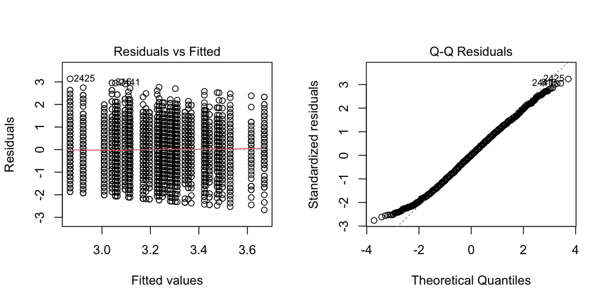

Residuals versus fitted values form a roughly random band of constant width, so the linearity and equal-variance assumptions hold. The normal Q–Q plot follows the reference line apart from mild movement in the tails, which is not a concern at n = 5 000.

# Appendix B — Variable Dictionary

The `.Rdata` file ships a `Variables_names` lookup table mapping each column to its full questionnaire wording. It is reproduced here so the loadings in Table 3 can be read without going back to the source data.

Table B-1. Column names and their questionnaire wording

| Column | Description |
| --- | --- |
| Sex | Sex |
| Age | Age |
| I | Introvert |
| S | Sensing |
| F | Feeling |
| C | Contextual |
| type | Four Letter Type |
| W1 | Practical People Oriented Service |
| W2 | Practical Technical Work |
| W3 | Creative Enrepeneur Work |
| W5 | Idealistiv Value Oriented Work |
| W6 | Gross Motor Work |
| W8 | Logical System Technical Work |
| W9 | Communication and Informative Work |
| W11 | Design Oriented Work |
| W12 | Technical Computations |
| W14 | Technical Problem Solving |
| W15 | Development and Change Oriented Work |
| W16 | Technical System Control |
| W17 | Humanitarian Service Work |
| W19 | Chaos and Change Oriented Work |
| W20 | Mathematical Computations |
| I1 | Practical Inductive Instruction |
| I3 | Abductive Theoretical Instruction |
| I4 | Dialog and Group Oriented Theoretical Instruction |
| I6 | Methodological Formula Oriented Instruction |
| I7 | Explorative Inspirational Instruction |
| I8 | Dialog based Inspirational Instruction |
| I9 | Practical Problem based Instruction |
| I10 | Instrumental Procedure Oriented Instruction |
| I12 | Non-directive Instruction |
| Chem | Chemistry |
| Bio | Biology |
| Geo | Geo Subjects |
| Math | Mathematics |
| Phys | Physics |
| Cplx | Complex Systems Technology |